# Hour 1 — EDA: Analyzing and predicting horror movie ratings in R

David Robinson’s analysis, extended | TheDataShrink™

Author

TheDataShrink™

Published

April 18, 2026

**TheDataShrink™ — Data stories worth sharing.**

Episode 003 · Hour 1

**Atomic Concepts in this episode**

**FAILS WHEN**

- outcome column is missing or near-zero variance
- training set is too small for the number of predictors
- text is multilingual without language detection
- join key has trailing whitespace or case inconsistency — produces unexpected NAs
- irregular time intervals inflate or deflate apparent trends

**WORKS WHEN**

- outcome column is clearly defined and has sufficient variance
- features can be engineered from existing columns without external joins
- text is long-form English and benefits from word-level decomposition
- time dimension is regular and spans multiple periods with meaningful change

```r
library(here)
library(scales)
library(tidyverse)
library(tidytext)
library(glmnet)
library(Matrix)
library(broom)

# TheDataShrink™ brand colours
TDS_BLUE  <- "#1b6ca8"
TDS_GOLD  <- "#c8a415"
TDS_DARK  <- "#1a1a2e"
TDS_LIGHT <- "#f8f9fa"
theme_set(theme_light(base_size = 13))
```

## 1 Explore

```r
library(tidyverse)
theme_set(theme_light())

horror_movies_raw <- readr::read_csv("https://raw.githubusercontent.com/rfordatascience/tidytuesday/master/data/2019/2019-10-22/horror_movies.csv")
```

```r
horror_movies <- horror_movies_raw |>
  arrange(desc(review_rating)) |>
  extract(title, "year", "\\((\\d\\d\\d\\d)\\)$", remove = FALSE, convert = TRUE) |>
  mutate(budget = parse_number(budget)) |>
  separate(plot, c("director", "cast_sentence", "plot"), extra = "merge", sep = "\\. ", fill = "right") |>
  distinct(title, .keep_all = TRUE)
```

```r
horror_movies |>
  count(genres, sort = TRUE)
```

```
# A tibble: 261 × 2
   genres                               n
   <chr>                            <int>
 1 Horror                            1048
 2 Horror| Thriller                   469
 3 Comedy| Horror                     245
 4 Horror| Mystery| Thriller          171
 5 Drama| Horror| Thriller            159
 6 Drama| Horror                       72
 7 Horror| Sci-Fi| Thriller            66
 8 Drama| Horror| Mystery| Thriller    53
 9 Action| Horror| Thriller            48
10 Horror| Mystery                     47
# ℹ 251 more rows
```

```r
horror_movies |>
  count(language, sort = TRUE)
```

```
# A tibble: 188 × 2
   language             n
   <chr>            <int>
 1 English           2407
 2 Spanish             94
 3 Japanese            75
 4 <NA>                70
 5 Hindi               37
 6 Filipino|Tagalog    34
 7 Thai                34
 8 English|Spanish     30
 9 Turkish             29
10 German              28
# ℹ 178 more rows
```

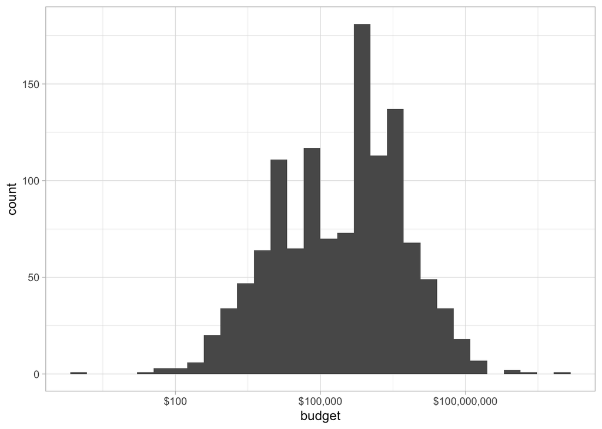

```r
horror_movies |>
  ggplot(aes(budget)) +
  geom_histogram() +
  scale_x_log10(labels = scales::dollar)
```

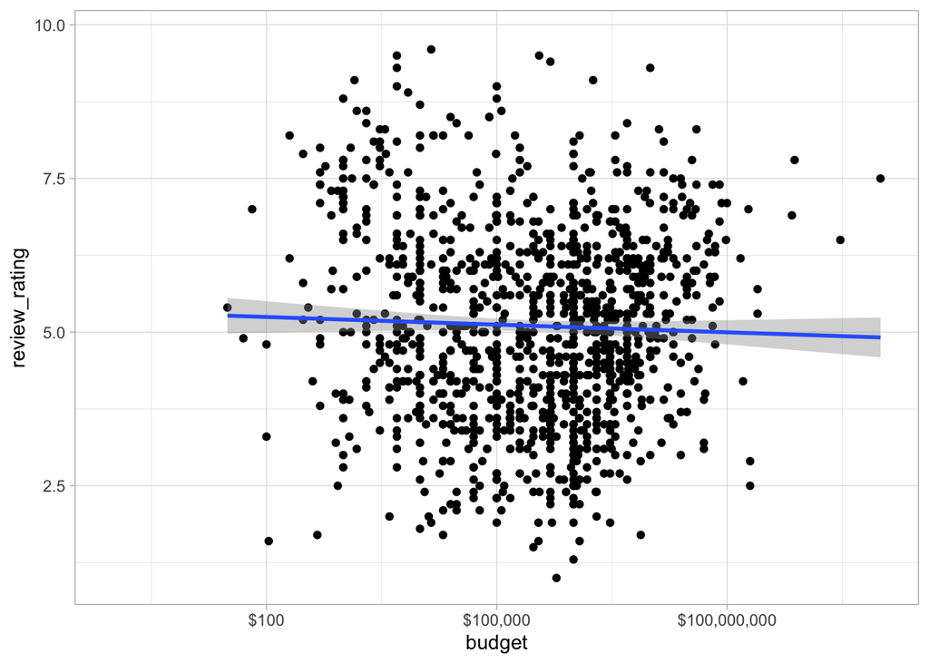

```r
horror_movies |>
  ggplot(aes(budget, review_rating)) +
  geom_point() +
  scale_x_log10(labels = scales::dollar) +
  geom_smooth(method = "lm")
```

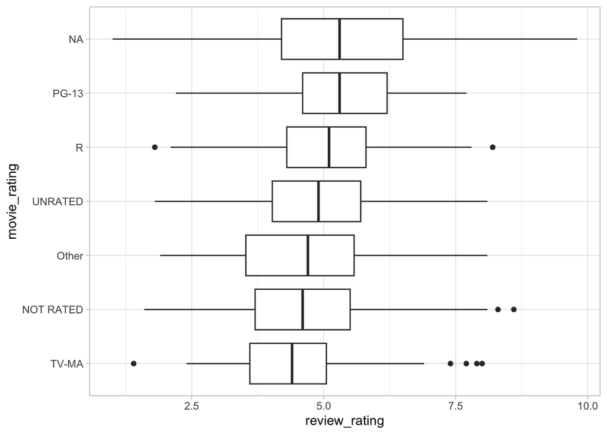

```r
horror_movies |>
  mutate(movie_rating = fct_lump(movie_rating, 5),
         movie_rating = fct_reorder(movie_rating, review_rating, na.rm = TRUE)) |>
  ggplot(aes(movie_rating, review_rating)) +
  geom_boxplot() +
  coord_flip()
```

```r
horror_movies |>
  filter(!is.na(movie_rating)) |>
  mutate(movie_rating = fct_lump(movie_rating, 5)) |>
  lm(review_rating ~ movie_rating, data = .) |>
  anova()
```

[output not shown]

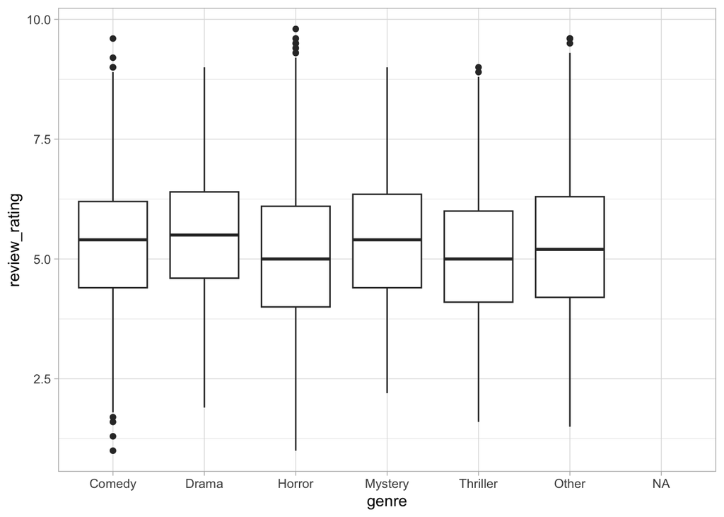

```r
horror_movies |>
  separate_rows(genres, sep = "\\| ") |>
  mutate(genre = fct_lump(genres, 5)) |>
  ggplot(aes(genre, review_rating)) +
  geom_boxplot()
```

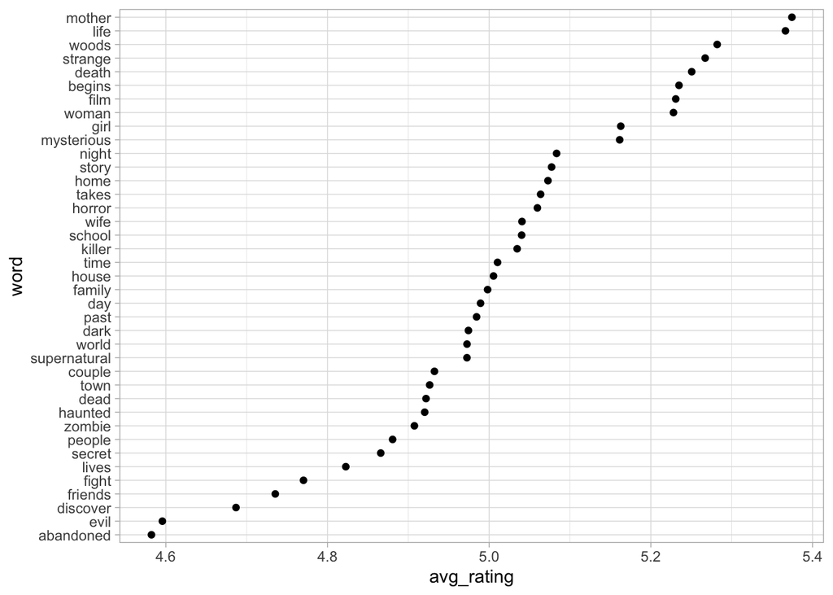

```r
library(tidytext)

horror_movies_unnested <- horror_movies |>
  unnest_tokens(word, plot) |>
  anti_join(stop_words, by = "word") |>
  filter(!is.na(word))

horror_movies_unnested |>
  filter(!is.na(review_rating)) |>
  group_by(word) |>
  summarize(movies = n(),
            avg_rating = mean(review_rating)) |>
  arrange(desc(movies)) |>
  filter(movies >= 100) |>
  mutate(word = fct_reorder(word, avg_rating)) |>
  ggplot(aes(avg_rating, word)) +
  geom_point()
```